# WEATHER FORECAST USING RECURRENT NEURAL NETWORK (RNN) BASED ON THE DATA OF AN ALBUQUERQUE TOWN IN THE TIME PERIOD 2012-2017.

## A recurrent neural network (RNN) is a type of neural network that is designed to process sequential data, such as time series data or natural language. RNNs have a "memory" component, known as a hidden state, which allows them to maintain information about previous inputs when processing new inputs. This allows them to make predictions or decisions based on the entire sequence of inputs, rather than just the current input. RNNs can be unrolled over time, giving a clear picture of the network's architecture. RNNs are widely used in a variety of applications such as speech recognition, natural language processing, and time series forecasting.

## Data loading and pre-processing

```python
import pandas as pd
import numpy as np
import matplotlib.pyplot as plt
pd.set_option('mode.chained_assignment', None)

from keras.models import Sequential
from keras.layers import Dense, SimpleRNN
from tensorflow.keras.optimizers.legacy import RMSprop
from keras.callbacks import Callback
```

```python
humidity = pd.read_csv("../weather-pogodynka/humidity.csv")
temp = pd.read_csv("../weather-pogodynka/temperature.csv")
pressure = pd.read_csv("../weather-pogodynka/pressure.csv")
```

```python
humidity_ALB = humidity[['datetime','Albuquerque']]
temp_ALB = temp[['datetime','Albuquerque']]
pressure_ALB = pressure[['datetime','Albuquerque']]
```

```python
#humidity_ALB.head(10)
pressure_ALB.head(10)
```

|  | datetime | Albuquerque |
| --- | --- | --- |
| 0 | 2012-10-01 12:00:00 | NaN |
| 1 | 2012-10-01 13:00:00 | 1024.0 |
| 2 | 2012-10-01 14:00:00 | 1024.0 |
| 3 | 2012-10-01 15:00:00 | 1024.0 |
| 4 | 2012-10-01 16:00:00 | 1024.0 |
| 5 | 2012-10-01 17:00:00 | 1024.0 |
| 6 | 2012-10-01 18:00:00 | 1024.0 |
| 7 | 2012-10-01 19:00:00 | 1024.0 |
| 8 | 2012-10-01 20:00:00 | 1024.0 |
| 9 | 2012-10-01 21:00:00 | 1024.0 |

```python
pressure_ALB.tail(10)
```

|  | datetime | Albuquerque |
| --- | --- | --- |
| 45243 | 2017-11-29 15:00:00 | 1028.0 |
| 45244 | 2017-11-29 16:00:00 | 1028.0 |
| 45245 | 2017-11-29 17:00:00 | 1028.0 |
| 45246 | 2017-11-29 18:00:00 | 1028.0 |
| 45247 | 2017-11-29 19:00:00 | 1026.0 |
| 45248 | 2017-11-29 20:00:00 | 1025.0 |
| 45249 | 2017-11-29 21:00:00 | 1024.0 |
| 45250 | 2017-11-29 22:00:00 | 1024.0 |
| 45251 | 2017-11-29 23:00:00 | 1024.0 |
| 45252 | 2017-11-30 00:00:00 | 1024.0 |

```python
print(humidity_ALB.shape)
print(temp_ALB.shape)
print(pressure_ALB.shape)
```

```
(45253, 2)
(45253, 2)
(45253, 2)
```

### There are many `NaN` values (Not a Numbers) in the dataset

```python
print("How many NaN are there in the humidity dataset?",humidity_ALB.isna().sum()['Albuquerque'])
print("How many NaN are there in the temperature dataset?",temp_ALB.isna().sum()['Albuquerque'])
print("How many NaN are there in the pressure dataset?",pressure_ALB.isna().sum()['Albuquerque'])
```

```
How many NaN are there in the humidity dataset? 710
How many NaN are there in the temperature dataset? 1
How many NaN are there in the pressure dataset? 456
```

### Choosing a point in the time-series for training data

```python
Tp = 7000
```

```python
def plot_train_points(quantity='humidity',Tp=7000):
    plt.figure(figsize=(15,4))
    if quantity=='humidity':
        plt.title("Humidity of first {} data points".format(Tp),fontsize=16)
        plt.plot(humidity_ALB['Albuquerque'][:Tp],c='k',lw=1)
    if quantity=='temperature':
        plt.title("Temperature of first {} data points".format(Tp),fontsize=16)
        plt.plot(temp_ALB['Albuquerque'][:Tp],c='k',lw=1)
    if quantity=='pressure':
        plt.title("Pressure of selected {} data points".format(Tp),fontsize=16)
        plt.plot(pressure_ALB['Albuquerque'][16300:23300],c='k',lw=1)
    plt.grid(True)
    plt.xticks(fontsize=14)
    plt.yticks(fontsize=14)
    plt.show()
```

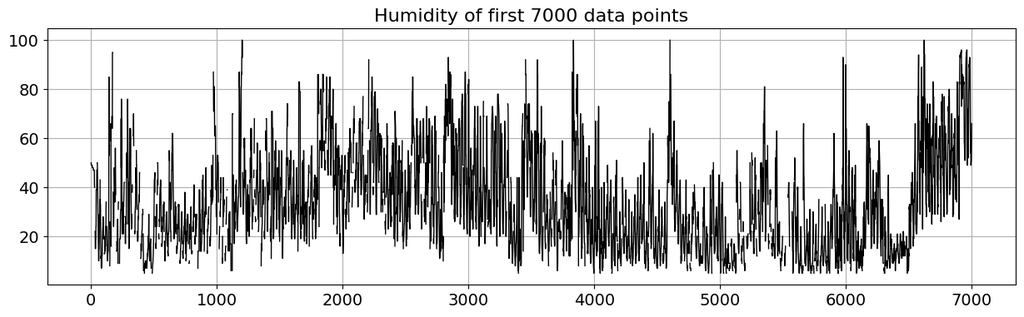

```python
plot_train_points('humidity')
```

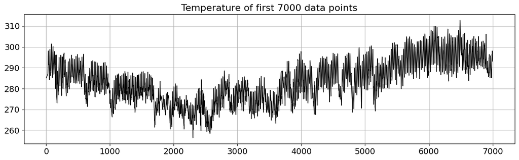

```python
plot_train_points('temperature')
```

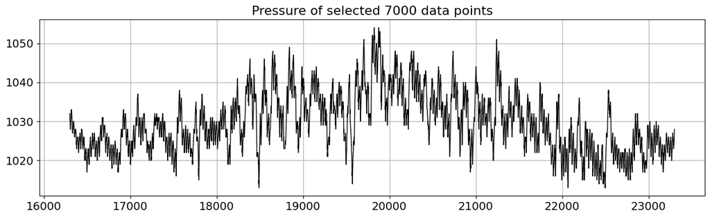

```python
plot_train_points('pressure')
```

### Interpolate data points to fill up `NaN` values

I observed some `NaN` values in the dataset. I could just eliminate these points. But assuming that the changes in the parameters are not extremely abrupt, I could try to fill them using simple linear interpolation.

```python
humidity_ALB.interpolate(inplace=True)
humidity_ALB.dropna(inplace=True)

temp_ALB.interpolate(inplace=True)
temp_ALB.dropna(inplace=True)

pressure_ALB.interpolate(inplace=True)
pressure_ALB.dropna(inplace=True)
```

```python
print(humidity_ALB.shape)
print(temp_ALB.shape)
print(pressure_ALB.shape)
```

```
(45252, 2)
(45252, 2)
(45252, 2)
```

### Train and test splits on the `Tp=7000`

```python
train = np.array(humidity_ALB['Albuquerque'][:Tp])
test = np.array(humidity_ALB['Albuquerque'][Tp:])
```

```python
print("Train data length:", train.shape)
print("Test data length:", test.shape)
```

```
Train data length: (7000,)
Test data length: (38252,)
```

```python
train=train.reshape(-1,1)
test=test.reshape(-1,1)
```

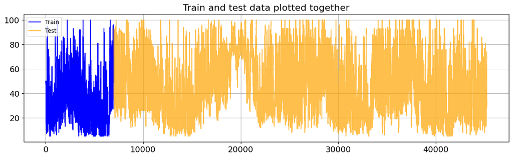

```python
plt.figure(figsize=(15,4))
plt.title("Train and test data plotted together",fontsize=16)
plt.plot(np.arange(Tp),train,c='blue')
plt.plot(np.arange(Tp,45252),test,c='orange',alpha=0.7)
plt.legend(['Train','Test'])
plt.grid(True)
plt.xticks(fontsize=14)
plt.yticks(fontsize=14)
plt.show()
```

### Choose the embedding or step size

RNN model requires a step value that contains n number of elements as an input sequence.

Suppose x = {1,2,3,4,5,6,7,8,9,10}

for step=1, x input and its y prediction become:

| x | y |
| --- | --- |
| 1 | 2 |
| 2 | 3 |
| 3 | 4 |
| ... | ... |
| 9 | 10 |

for step=3, x and y contain:

| x | y |
| --- | --- |
| 1,2,3 | 4 |
| 2,3,4 | 5 |
| 3,4,5 | 6 |
| ... | ... |
| 7,8,9 | 10 |

Here, i choosed `step=8`. In more complex RNN and in particular for text processing, this is also called *embedding size*. The idea here is that **I'm assuming that 8 hours of Iather data can effectively predict the 9th hour data, and so on.**

```python
step = 8
```

```python
# add step elements into train and test
test = np.append(test,np.repeat(test[-1,],step))
train = np.append(train,np.repeat(train[-1,],step))
```

```python
print("Train data length:", train.shape)
print("Test data length:", test.shape)
```

```
Train data length: (7008,)
Test data length: (38260,)
```

### Converting to a multi-dimensional array

Next, i'll convert test and train data into the matrix with step value as it has shown above example.

```python
def convertToMatrix(data, step):
    X, Y =[], []
    for i in range(len(data)-step):
        d=i+step
        X.append(data[i:d,])
        Y.append(data[d,])
    return np.array(X), np.array(Y)
```

```python
trainX,trainY =convertToMatrix(train,step)
testX,testY =convertToMatrix(test,step)
```

```python
trainX = np.reshape(trainX, (trainX.shape[0], 1, trainX.shape[1]))
testX = np.reshape(testX, (testX.shape[0], 1, testX.shape[1]))
```

```python
print("Training data shape:", trainX.shape,', ',trainY.shape)
print("Test data shape:", testX.shape,', ',testY.shape)
```

```
Training data shape: (7000, 1, 8) ,  (7000,)
Test data shape: (38252, 1, 8) ,  (38252,)
```

## Modeling

### Keras model with `SimpleRNN` layer

I build a simple function to define the RNN model. It uses a single neuron for the output layer because i'm predicting a real-valued number here. As activation, it uses the ReLU function. Following arguments are supported.

- neurons in the RNN layer
- embedding length (i.e. the step length I chose)
- neurons in the densely connected layer
- learning rate

```python
def build_simple_rnn(num_units=128, embedding=4,num_dense=32,lr=0.001):
    """
    Builds and compiles a simple RNN model
    Arguments:
              num_units: Number of units of a the simple RNN layer
              embedding: Embedding length
              num_dense: Number of neurons in the dense layer folloId by the RNN layer
              lr: Learning rate (uses RMSprop optimizer)
    Returns:
              A compiled Keras model.
    """
    model = Sequential()
    model.add(SimpleRNN(units=num_units, input_shape=(1,embedding), activation="relu"))
    model.add(Dense(num_dense, activation="relu"))
    model.add(Dense(1))
    model.compile(loss='mean_squared_error', optimizer=RMSprop(lr=lr),metrics=['mse'])

    return model
```

```python
model_humidity = build_simple_rnn(num_units=128,num_dense=32,embedding=8,lr=0.0005)
```

```python
model_humidity.summary()
```

```
Model: "sequential_3"
_________________________________________________________________
 Layer (type)                Output Shape              Param #
=================================================================
 simple_rnn_3 (SimpleRNN)    (None, 128)               17536

 dense_6 (Dense)             (None, 32)                4128

 dense_7 (Dense)             (None, 1)                 33

=================================================================
Total params: 21,697
Trainable params: 21,697
Non-trainable params: 0
_________________________________________________________________
```

### A simple Keras `Callback` class to print progress of the training at regular epoch interval

Since the RNN training is usually long, I want to see regular updates about epochs finishing. HoIver, I may not want to see this update every epoch as that may flood the output stream. Therefore, I write a simple custom `Callback` function to print the finishing update every 50th epoch. You can think of adding other bells and whistles to this function to print error and other metrics dynamically.

```python
class MyCallback(Callback):
    def on_epoch_end(self, epoch, logs=None):
        if (epoch+1) % 50 == 0 and epoch>0:
            print("Epoch number {} done".format(epoch+1))
```

### Batch size and number of epochs

```python
batch_size=8
num_epochs = 1000
```

### Training the model

```python
model_humidity.fit(trainX,trainY,
          epochs=num_epochs,
          batch_size=batch_size,
          callbacks=[MyCallback()],verbose=0)
```

```
Epoch number 50 done
Epoch number 100 done
Epoch number 150 done
Epoch number 200 done
Epoch number 250 done
Epoch number 300 done
Epoch number 350 done
Epoch number 400 done
Epoch number 450 done
Epoch number 500 done
Epoch number 550 done
Epoch number 600 done
Epoch number 650 done
Epoch number 700 done
Epoch number 750 done
Epoch number 800 done
Epoch number 850 done
Epoch number 900 done
Epoch number 950 done
Epoch number 1000 done
```

```
<keras.callbacks.History at 0x230b59bba30>
```

### Plot RMSE loss over epochs

Note that the `loss` metric available in the `history` attribute of the model is the MSE loss and you have to take a square-root to compute the RMSE loss.

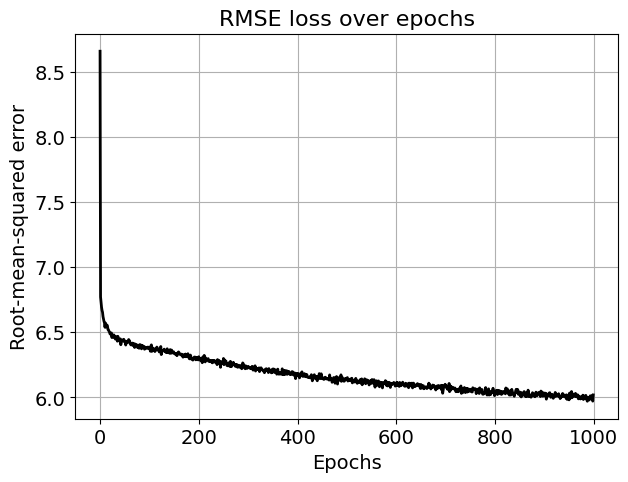

```python
plt.figure(figsize=(7,5))
plt.title("RMSE loss over epochs",fontsize=16)
plt.plot(np.sqrt(model_humidity.history.history['loss']),c='k',lw=2)
plt.grid(True)
plt.xlabel("Epochs",fontsize=14)
plt.ylabel("Root-mean-squared error",fontsize=14)
plt.xticks(fontsize=14)
plt.yticks(fontsize=14)
plt.show()
```

## Result and analysis

### What did the model see while training?

I'm emphasizing and showing again what exactly the model see during training. If you look above, the model fitting code is,

```
model_humidity.fit(trainX,trainY,
          epochs=num_epochs,
          batch_size=batch_size,
          callbacks=[MyCallback()],verbose=0)
```

So, the model was fitted with `trainX` which is plotted below, and `trainY` which is just the 8 step shifted and shaped vector.

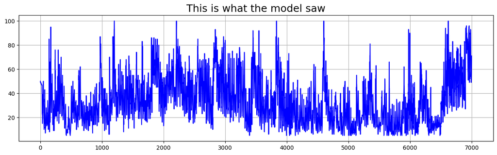

```python
plt.figure(figsize=(15,4))
plt.title("This is what the model saw",fontsize=18)
plt.plot(trainX[:,0][:,0],c='blue')
plt.grid(True)
plt.show()
```

### Now predict the future points

Now, I can generate predictions for the future by passing `testX` to the trained model.

```python
trainPredict = model_humidity.predict(trainX)
testPredict= model_humidity.predict(testX)
predicted=np.concatenate((trainPredict,testPredict),axis=0)
```

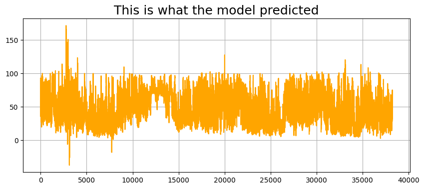

```python
plt.figure(figsize=(10,4))
plt.title("This is what the model predicted",fontsize=18)
plt.plot(testPredict,c='orange')
plt.grid(True)
plt.show()
```

### Plotting the ground truth and model predictions together

I plotted the ground truth and the model predictions together to show that it follows the general trends in the ground truth data pretty Ill. Considering less than 25% data was used for training, this is sort of amazing. The boundary betIen train and test splits is denoted by the vertical red line.

There are, of course, some obvious mistakes in the model predictions, such as humidity values going above 100 and some very low values. These can be pruned with post-processing or a better model can be built with proper hyperparameter tuning.

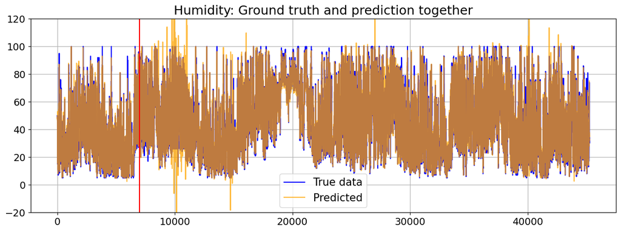

```python
index = humidity_ALB.index.values

plt.figure(figsize=(15,5))
plt.title("Humidity: Ground truth and prediction together",fontsize=18)
plt.plot(index,humidity_ALB['Albuquerque'],c='blue')
plt.plot(index,predicted,c='orange',alpha=0.75)
plt.legend(['True data','Predicted'],fontsize=15)
plt.axvline(x=Tp, c="r")
plt.grid(True)
plt.xticks(fontsize=14)
plt.yticks(fontsize=14)
plt.ylim(-20,120)
plt.show()
```

## Modeling the temperature data

Since I have covered modeling the humidity data step-by-step in detail, I will show the modeling with other two parameters - temperature and pressure - in a simpler manner.

```python
train = np.array(temp_ALB['Albuquerque'][:Tp])
test = np.array(temp_ALB['Albuquerque'][Tp:])

train=train.reshape(-1,1)
test=test.reshape(-1,1)

step = 8

# add step elements into train and test
test = np.append(test,np.repeat(test[-1,],step))
train = np.append(train,np.repeat(train[-1,],step))

trainX,trainY =convertToMatrix(train,step)
testX,testY =convertToMatrix(test,step)

trainX = np.reshape(trainX, (trainX.shape[0], 1, trainX.shape[1]))
testX = np.reshape(testX, (testX.shape[0], 1, testX.shape[1]))
```

```python
model_temp = build_simple_rnn(num_units=128,num_dense=32,embedding=8,lr=0.0005)

batch_size=8
num_epochs = 2000

model_temp.fit(trainX,trainY,
          epochs=num_epochs,
          batch_size=batch_size,
          callbacks=[MyCallback()],verbose=0)
```

```
Epoch number 50 done
Epoch number 100 done
Epoch number 150 done
Epoch number 200 done
Epoch number 250 done
Epoch number 300 done
Epoch number 350 done
Epoch number 400 done
Epoch number 450 done
Epoch number 500 done
Epoch number 550 done
Epoch number 600 done
Epoch number 650 done
Epoch number 700 done
Epoch number 750 done
Epoch number 800 done
Epoch number 850 done
Epoch number 900 done
Epoch number 950 done
Epoch number 1000 done
Epoch number 1050 done
Epoch number 1100 done
Epoch number 1150 done
Epoch number 1200 done
Epoch number 1250 done
Epoch number 1300 done
Epoch number 1350 done
Epoch number 1400 done
Epoch number 1450 done
Epoch number 1500 done
Epoch number 1550 done
Epoch number 1600 done
Epoch number 1650 done
Epoch number 1700 done
Epoch number 1750 done
Epoch number 1800 done
Epoch number 1850 done
Epoch number 1900 done
Epoch number 1950 done
Epoch number 2000 done
```

```
<keras.callbacks.History at 0x230b5cc2e00>
```

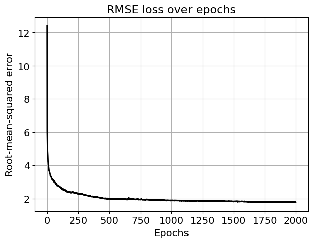

```python
plt.figure(figsize=(7,5))
plt.title("RMSE loss over epochs",fontsize=16)
plt.plot(np.sqrt(model_temp.history.history['loss']),c='k',lw=2)
plt.grid(True)
plt.xlabel("Epochs",fontsize=14)
plt.ylabel("Root-mean-squared error",fontsize=14)
plt.xticks(fontsize=14)
plt.yticks(fontsize=14)
plt.show()
```

```python
trainPredict = model_temp.predict(trainX)
testPredict= model_temp.predict(testX)
predicted=np.concatenate((trainPredict,testPredict),axis=0)
```

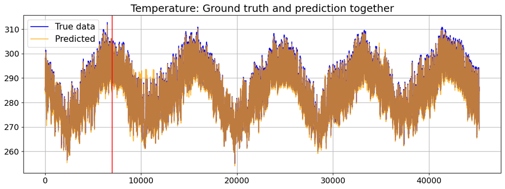

```python
index = temp_ALB.index.values

plt.figure(figsize=(15,5))
plt.title("Temperature: Ground truth and prediction together",fontsize=18)
plt.plot(index,temp_ALB['Albuquerque'],c='blue')
plt.plot(index,predicted,c='orange',alpha=0.75)
plt.legend(['True data','Predicted'],fontsize=15)
plt.axvline(x=Tp, c="r")
plt.grid(True)
plt.xticks(fontsize=14)
plt.yticks(fontsize=14)
plt.show()
```

```python
train = np.array(pressure_ALB['Albuquerque'][:Tp])
test = np.array(pressure_ALB['Albuquerque'][Tp:])

train=train.reshape(-1,1)
test=test.reshape(-1,1)

step = 8

# add step elements into train and test
test = np.append(test,np.repeat(test[-1,],step))
train = np.append(train,np.repeat(train[-1,],step))

trainX,trainY =convertToMatrix(train,step)
testX,testY =convertToMatrix(test,step)

trainX = np.reshape(trainX, (trainX.shape[0], 1, trainX.shape[1]))
testX = np.reshape(testX, (testX.shape[0], 1, testX.shape[1]))
```

```python
model_pressure= build_simple_rnn(num_units=128,num_dense=32,embedding=8,lr=0.0005)

batch_size=8
num_epochs = 500

model_pressure.fit(trainX,trainY,
          epochs=num_epochs,
          batch_size=batch_size,
          callbacks=[MyCallback()],verbose=0)
```

```
Epoch number 50 done
Epoch number 100 done
Epoch number 150 done
Epoch number 200 done
Epoch number 250 done
Epoch number 300 done
Epoch number 350 done
Epoch number 400 done
Epoch number 450 done
Epoch number 500 done
```

```
<keras.callbacks.History at 0x230bc8b7940>
```

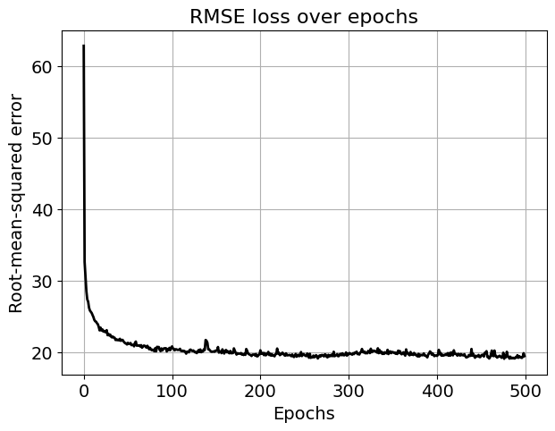

```python
plt.figure(figsize=(7,5))
plt.title("RMSE loss over epochs",fontsize=16)
plt.plot(np.sqrt(model_pressure.history.history['loss']),c='k',lw=2)
plt.grid(True)
plt.xlabel("Epochs",fontsize=14)
plt.ylabel("Root-mean-squared error",fontsize=14)
plt.xticks(fontsize=14)
plt.yticks(fontsize=14)
plt.show()
```

```python
trainPredict = model_pressure.predict(trainX)
testPredict= model_pressure.predict(testX)
predicted=np.concatenate((trainPredict,testPredict),axis=0)
```

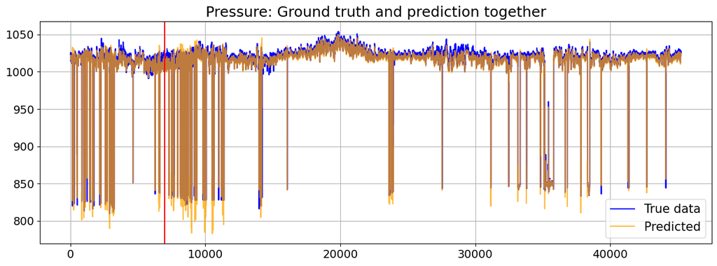

```python
index = pressure_ALB.index.values

plt.figure(figsize=(15,5))
plt.title("Pressure: Ground truth and prediction together",fontsize=18)
plt.plot(index,pressure_ALB['Albuquerque'],c='blue')
plt.plot(index,predicted,c='orange',alpha=0.75)
plt.legend(['True data','Predicted'],fontsize=15)
plt.axvline(x=Tp, c="r")
plt.grid(True)
plt.xticks(fontsize=14)
plt.yticks(fontsize=14)
plt.show()
```

**The prediction is semi accurate due to taking just 7000 data points but it still manages to predict future values with acceptable deviation. Even with the spikes of the pressure prediction manages to have close values to the real one.